# notebook

MICROESTRUCTURA Y SISTEMAS DE TRADING

Ingeniería financiera

Ivette Landaverde Mercado

Junio 2022. | Repository: [Link](https://github.com/IvetteLandaverde/Laboratorio-1)

Laboratorio 1  
Libros de ordenes y Trades públicos.

# 1. Introducción

Este notebook contiene el laboratorio No. 1 de la clase Microestructuras y Sistemas de Trading, verano 2022. Es un acercamiento inicial a las métricas de libros de ordenes y trades públicas que se estarán utilizando durante todo el periodo.

## 2.1 Python Packages

Para poder ejecutar este notebook es necesario tener instalado y/o tener el archivo *requirements.txt* con lo siguiente:

- pandas>=1.1.1
- numpy>=1.19.1
- jupyter>=1.0.0

## 2.2 Files Dependencies

Se necesitan los siguientes archivos para poder ejecutar el notebook:

- btcusdt_binance.csv
- orderbooks_05jul21.json
- data.py
- functions.py
- visualizations.py
- main.py
- files/datos.txt : Otros datos históricos

## 2.3 Install Packages

```python
%%capture

# Install all the pip packages in the requirements.txt
import sys
!{sys.executable} -m pip install -r requirements.txt
```

```python
import numpy as np
import pandas as pd
import data as dt
import functions as fn
```

# 3. Data Description

Los datos utilizados para este laboratorio fueron los siguientes:

- Libros de ordenes:

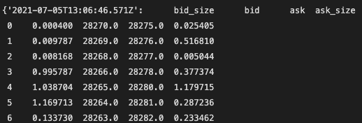

- Trades públicos

# 3.1 Libros de ordenes

Un libro de órdenes u Order Book por su nombre en inglés, es una lista de operaciones, ya sean electrónicas o manuales, que una bolsa utiliza para registrar el interés del mercado en un valor específico o instrumento financiero. Las acciones se cotizan normalmente en un libro de órdenes por volumen y por nivel de precios. Se actualiza en el tiempo real y permite medir el "sentimiento" del mercado en un determinado momento.

## Métricas:

Las métricas calculadas fueron las siguientes:

- Median time of order books update
- Spread
- Midprice
- No. Price levels
- Bid Volume
- Ask Volume
- Total Volume
- Volume Imbalance
- Weighted Midprice
- Volume-Weighted Average Price
- Resumen metricas OB

###### Median time of order books update

- median_time_OB(ob_data)

###### Spread

- spread_OB(ob_data)

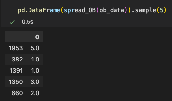

###### Midprice

- midprice_ob(ob_data)

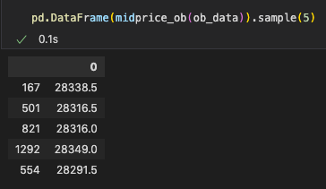

###### No price levels

- price_levels_OB(ob_data)

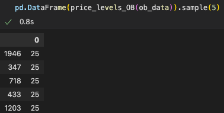

###### Bid volume

- bid_volume_OB(ob_data)

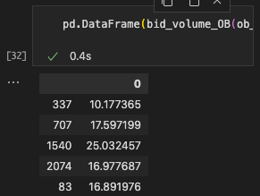

###### Ask volume

- ask_volume_OB(ob_data)

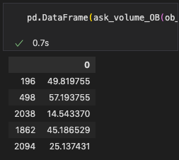

###### Total volume

- total_volume_OB(ob_data)

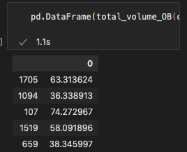

###### Volume imbalance

- volume_imbalance_OB(ob_data)

##### Weighted Midprice

- WMA_OB(ob_data)

##### Volume-Weighted Average Price

- VWA_price_OB(ob_data)

##### Resumen metricas OB

- resumen_OB

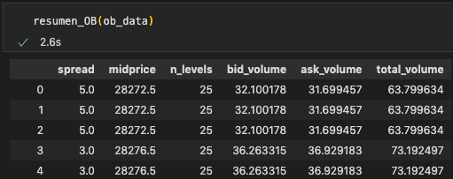

##### Conclusión:

El medir la manera en que el intercambio de compra/venta afecta los precios de un activo no refleja completamente su comportamiento, algunas veces no brinda información relevante.